# 特征工程(二)

## 0.1 离群值识别和处理

离群值是指数据集的每个变量中孤立于其他数据点的对象。在数据的收集中，由于各种因素的影响，离群点是很难避免的。尤其在人工输入数据的时候，经常会出现小数点输入错误的问题，比如123.12误输入为1231.2。

离群点同样会对数据挖掘产生一定的影响，如果不做离群点的处理，那么模型的输入就是存在偏差的。可想而知，一个有偏差的输入，很难得出无偏差的输出。

### 0.1.1 离群点识别

在 R 中识别离群点的方法同样有很多，比如可视化方向的箱线图、统计学方向的高杠杆值点、dffits值、学生化残差、cook距离等。不过统计学方向的识别方法是基于回归的，现在学习这个有些吃力，所以在此我就只简单的介绍通用的可视化方法。

绘制箱线图也有很多种函数，比如**boxplot()**、**geom_boxplot()**、**plot_ly()**等。箱线图会让我们方便的了解某个变量的分布情况，并且会把离群点(上边缘以上和下边缘以下)标记出来。不过对于含有较多离群点的变量来说，其返回的结果不能清晰的看到离群点的具体个数。

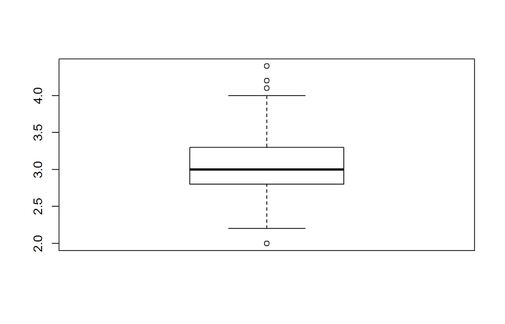

```r
boxplot(iris$Sepal.Width) # 绘制箱线图
```

### 0.1.2 离群点处理

针对于离群点的处理方法主要是：直接剔除含有异常值的观测、视为缺失值处理、均值修正(前后两个观测的均值替换)、用特定值替换(一般用于知道离群点出现的原因)。同样，处理的方法也是各有千秋。

需要注意的是，并不是说离群点必须要做处理。如果说离群点是一个正确的数据，比如说公司中不同职位的员工的工资汇总表就会出现很多离群点，所以说在很多情况下则可以直接进行挖掘。由于这个离群点的处理大都是由业务需求决定的，所以后面只演示剔除某个值以上的离群点。

后面的代码中会出现**%>%**，这个是dplyr包里面的管道函数。这个函数就是把前面的数据作为一个参数，传入后面的函数中，默认作为第一个参数，当然也可以自定义参数的位置。

注：**%>%**非常好用，在R中可以说是至关重要的一个函数，强烈建议大家多去使用此函数！

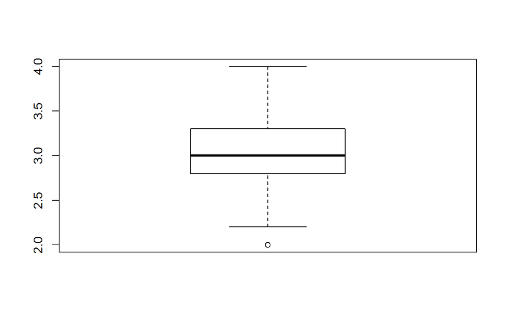

```r
# install.packages("dplyr")
library(dplyr)                                # filter()

## 假设需要剔除Sepal.Width的长度大于4的观测
iris.new <- iris %>% filter(Sepal.Width <= 4) # 筛选出Sepal.Width小于等于4的观测

# 绘制箱线图验证是否处理成功
boxplot(iris.new$Sepal.Width) # 绘制箱线图
```

## 0.2 无量纲化

无量纲化就是消除量纲影响，量纲是表征物理量的性质(类别)，如时间、长度、质量等。那么不同的量纲又有什么影响呢？举个例子：若是研究成年男性的身高、年龄对于体重的影响，那么身高一般是150-190cm，而年龄则是18-100岁。若是直接将此数据对体重就行拟合，那么则很容易去强化某一变量而弱化另一变量的作用。

消除量纲最常用的两种方法是就是标准化和归一化。以下进行无量纲化操作使用的数据是R自带的Puromycin数据集。因为在此只为了进行单纯的无量纲化处理，所以就不去详细解释此数据集了，有兴趣的可以在R中输入`?Puromycin`命令去查看数据的详细信息。

```r
# install.packages("DT")
library(DT)

data("Puromycin")
datatable(Puromycin)
```

|  | conc | rate | state |
| --- | --- | --- | --- |
| 1 | 0.02 | 76 | treated |
| 2 | 0.02 | 47 | treated |
| 3 | 0.06 | 97 | treated |
| 4 | 0.06 | 107 | treated |
| 5 | 0.11 | 123 | treated |
| 6 | 0.11 | 139 | treated |
| 7 | 0.22 | 159 | treated |
| 8 | 0.22 | 152 | treated |
| 9 | 0.56 | 191 | treated |
| 10 | 0.56 | 201 | treated |

[output cut: 13 more lines]

### 0.2.1 标准化

简单的说，标准化就是按照特征矩阵的列处理数据，通过使用z-score的方法，转换为标准正态分布。在R中使用**scale()**函数就可以简单的将数据进行标准化，该函数使用的是z-score标准化方法，该方法原理如下：
$$X_{new}=\frac{X-\mu}{\sigma}=\frac{X-Mean(X)}{StdDev(X)}$$

```r
## 对数据的第一列和第二列进行标准化，并把处理后的数据赋值给Puromycin.sacle
Puromycin.scale <- scale(Puromycin[, 1:2])
datatable(Puromycin.scale)
```

|  | conc | rate |
| --- | --- | --- |
| 1 | -0.80459913981684 | -1.06972332353275 |
| 2 | -0.80459913981684 | -1.68007871856812 |
| 3 | -0.694445686151439 | -0.627741830576107 |
| 4 | -0.694445686151439 | -0.417274452977704 |
| 5 | -0.556753869069688 | -0.0805266488202585 |
| 6 | -0.556753869069688 | 0.256221155337187 |
| 7 | -0.253831871489837 | 0.677155910533993 |
| 8 | -0.253831871489837 | 0.529828746215111 |
| 9 | 0.68247248466607 | 1.35065151884888 |
| 10 | 0.68247248466607 | 1.56111889644729 |

[output cut: 13 more lines]

### 0.2.2 归一化

与标准化不同的是，归一化只是将样本的特征值转换到同一量纲下把数据映射到[0,1]区间内，却没有使数据标准化的作用。在R中最常用的归一化就是min-max方法，其原理如下：
$$X_{new}=\frac{X-min(X)}{max(X)-min(X)}$$

```r
## 笨方法——封装函数
# 封装归一化函数
normalize <- function(x) {
  return((x - min(x)) / (max(x) - min(x)))
}

## 对数据的前两列进行归一化
Puromycin.nor <-
  lapply(Puromycin[1:2], normalize) %>% # 进行标准化，返回列表
  data.frame()                          # 将列表转换为数据框

datatable(Puromycin.nor)
```

|  | conc | rate |
| --- | --- | --- |
| 1 | 0 | 0.18125 |
| 2 | 0 | 0 |
| 3 | 0.037037037037037 | 0.3125 |
| 4 | 0.037037037037037 | 0.375 |
| 5 | 0.0833333333333333 | 0.475 |
| 6 | 0.0833333333333333 | 0.575 |
| 7 | 0.185185185185185 | 0.7 |
| 8 | 0.185185185185185 | 0.65625 |
| 9 | 0.5 | 0.9 |
| 10 | 0.5 | 0.9625 |

[output cut: 13 more lines]

```r
## 好方法
# install.packages("caret")
library(caret)

data("Puromycin")                                   # 获取数据
standard <- preProcess(Puromycin, method = 'range') # 针对数据设定归一化方法
datatable(predict(standard, Puromycin))             # 对数据进行归一化
```

|  | conc | rate | state |
| --- | --- | --- | --- |
| 1 | 0 | 0.18125 | treated |
| 2 | 0 | 0 | treated |
| 3 | 0.037037037037037 | 0.3125 | treated |
| 4 | 0.037037037037037 | 0.375 | treated |
| 5 | 0.0833333333333333 | 0.475 | treated |
| 6 | 0.0833333333333333 | 0.575 | treated |
| 7 | 0.185185185185185 | 0.7 | treated |
| 8 | 0.185185185185185 | 0.65625 | treated |
| 9 | 0.5 | 0.9 | treated |
| 10 | 0.5 | 0.9625 | treated |

[output cut: 13 more lines]

心细的同学们肯定发现两种方法代入的数据有所不同，笨方法中指定对前两列进行归一化，而好方法中则不需指定。这正是笨方法与好方法的区别：好方法可以自动识别数值进行标准化，避免繁琐的操作。

## 0.3 特征重编码

特征重编码就是把数据集中的变量值进行重塑，无论是定量特征还是定性特征都可以进行重编码。比如说把“性别”这个定性变量中的“男”、“女”重塑为“0”、“1”。这样做的目的主要就是为了让数据适应不同的算法要求，因为不同的算法对数据类型的要求不同。

### 0.3.1 定量特征重塑

针对于定量特征的重编码主要就是二值化。常用于概率模型中，将概率小于等于0.5的转换为0，否则转换为1。

下面我们随机生成10个0-1之间的随机数，然后进行二值化变换。

```r
set.seed(45)
mydata <- runif(10, 0, 1) # 生成10个0-1之间的随机数

# 对其进行二值化变换，小于等于0.5的赋值为0，否则赋值为1
mydata.new <- ifelse(mydata <= 0.5, 0, 1)
```

### 0.3.2 定性特征重塑

针对于定性特征的重编码主要就是构建独热(One-Hot)编码。简而言之，就是将一个包含n个特征的变量转换为n个变量，转换后的变量中只会出现0、1两个特征。

下面我们构建一个拥有三个特征的变量，然后进行独热编码。

```r
# 构建一个数据框，赋值为mydata，并展示数据集
mydata <- data.frame(letters = c("A", "B", "C", "A", "C")); mydata
```

```
##   letters
## 1       A
## 2       B
## 3       C
## 4       A
## 5       C
```

```r
# install.packages("dummies")
library(dummies)

# 对mydata进行独热编码，赋值为mydata.oh，并展示数据
mydata.oh <- dummy.data.frame(mydata, names = c('letters'), sep = '.'); mydata.oh
```

```
##   letters.A letters.B letters.C
## 1         1         0         0
## 2         0         1         0
## 3         0         0         1
## 4         1         0         0
## 5         0         0         1
```